# Zwischenbericht MSB

### 2.4.4 Unterrichtsbesuche: Nützlichkeit aus Sicht der ALK

Sorry too lazy. This is from the codebook:

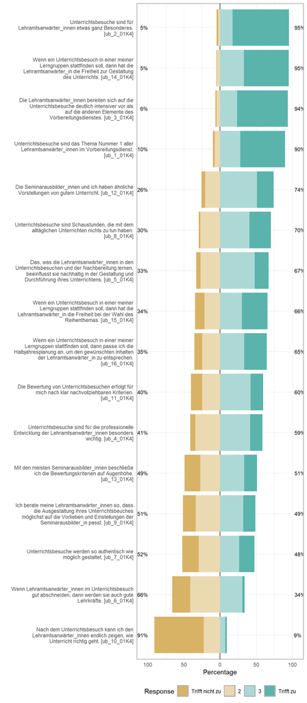

### 2.4.5 Zeitaufwand UB (Eigener)

**Abbildung**

```r
rm(p_var)
rm(p_vergleich)
rm(p_kohorten)
rm(p_gruppe)

############################################### #
### Welche VARIABLE soll ausgegeben werden?   ###
############################################### #
p_var <- "ubvorA_1" # Variable in Anführungszeichen angeben

############################################### #
### Welcher VERGLEICH soll angestellt werden? ###
############################################### #
p_vergleich <- "gruppe" # Möglich ist: "kohorte" oder "gruppe"

############################################### #
### Welche KOHORTEN sollen ausgegeben werden? ###
############################################### #
# p_kohorten <- c("3", "4") # Verfügbar: "1", "2", "3", "4"
                          # Einfach auskommentieren, wenn
                          # alle ausgegeben werden sollen

############################################### #
### Welche GRUPPEN sollen ausgegeben werden?  ###
############################################### #
# p_gruppe <- c("laa") # Verfügbar: "laa" (Lehramtsanwärter*innen),
                     #            "sab" (Seminarausbilder*innen)
                     #            "alk" (Ausbildungslehrkräfte)
                     # Einfach auskommentieren, wenn
                     # alle ausgegeben werden sollen

nrw_p <- nrw
if (exists("p_kohorten")) {
  nrw_p <- nrw_p |>
    dplyr::filter(kohorte %in% p_kohorten)
}
if (exists("p_gruppe")) {
  nrw_p <- nrw_p |>
    dplyr::filter(gruppe %in% p_gruppe)
}
```

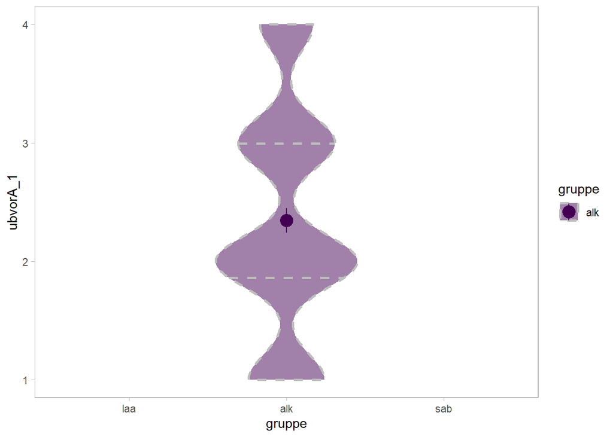

```r
violin_plot(nrw_p,
            eval(p_var),
            eval(p_vergleich))
```

**Deskriptive Ergebnisse**

In der Spalte “group1” wird angezeigt, um welche Gruppe (Nummer der Kohorte oder Gruppe) es sich in der jeweiligen Zeile handelt

```r
psych::describeBy(nrw_p[[p_var]],
                  group = droplevels(nrw_p[[p_vergleich]]),
                  mat=TRUE,
                  digits=3)
```

```
    item group1 vars   n  mean    sd median trimmed   mad min  max range  skew
X11    1    laa    1   0   NaN    NA     NA     NaN    NA Inf -Inf  -Inf    NA
X12    2    alk    1 319 2.345 0.965      2   2.307 1.483   1    4     3 0.233
X13    3    sab    1   0   NaN    NA     NA     NaN    NA Inf -Inf  -Inf    NA
    kurtosis    se
X11       NA    NA
X12   -0.908 0.054
X13       NA    NA
```

**Kohorten und Gruppen mit Daten**

Anzahl der Teilnehmenden je Gruppe und Kohorte:

```r
nrw %>%
  dplyr::filter(!is.na(get(p_var))) %>%
  {table(.$gruppe, .$kohorte)}
```

```
        1   2   3   4
  laa   0   0   0   0
  alk   0   0   0 319
  sab   0   0   0   0
```

### 2.4.6 Zeitaufwand UB (LAA aus Sicht der ALK)

**Abbildung**

```r
rm(p_var)
rm(p_vergleich)
rm(p_kohorten)
rm(p_gruppe)

############################################### #
### Welche VARIABLE soll ausgegeben werden?   ###
############################################### #
p_var <- "ubvorB_1" # Variable in Anführungszeichen angeben

############################################### #
### Welcher VERGLEICH soll angestellt werden? ###
############################################### #
p_vergleich <- "gruppe" # Möglich ist: "kohorte" oder "gruppe"

############################################### #
### Welche KOHORTEN sollen ausgegeben werden? ###
############################################### #
# p_kohorten <- c("3", "4") # Verfügbar: "1", "2", "3", "4"
                          # Einfach auskommentieren, wenn
                          # alle ausgegeben werden sollen

############################################### #
### Welche GRUPPEN sollen ausgegeben werden?  ###
############################################### #
# p_gruppe <- c("laa") # Verfügbar: "laa" (Lehramtsanwärter*innen),
                     #            "sab" (Seminarausbilder*innen)
                     #            "alk" (Ausbildungslehrkräfte)
                     # Einfach auskommentieren, wenn
                     # alle ausgegeben werden sollen

nrw_p <- nrw
if (exists("p_kohorten")) {
  nrw_p <- nrw_p |>
    dplyr::filter(kohorte %in% p_kohorten)
}
if (exists("p_gruppe")) {
  nrw_p <- nrw_p |>
    dplyr::filter(gruppe %in% p_gruppe)
}
```

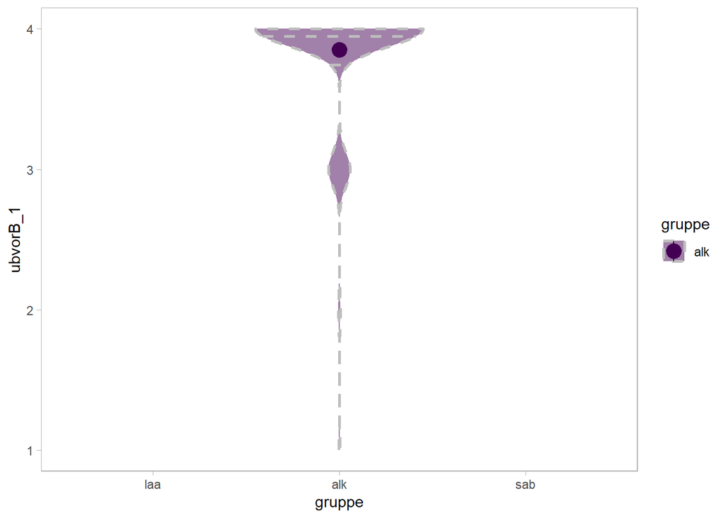

```r
violin_plot(nrw_p,
            eval(p_var),
            eval(p_vergleich))
```

**Deskriptive Ergebnisse**

In der Spalte “group1” wird angezeigt, um welche Gruppe (Nummer der Kohorte oder Gruppe) es sich in der jeweiligen Zeile handelt

```r
psych::describeBy(nrw_p[[p_var]],
                  group = droplevels(nrw_p[[p_vergleich]]),
                  mat=TRUE,
                  digits=3)
```

```
    item group1 vars   n mean   sd median trimmed mad min  max range   skew
X11    1    laa    1   0  NaN   NA     NA     NaN  NA Inf -Inf  -Inf     NA
X12    2    alk    1 319 3.85 0.43      4   3.961   0   1    4     3 -3.408
X13    3    sab    1   0  NaN   NA     NA     NaN  NA Inf -Inf  -Inf     NA
    kurtosis    se
X11       NA    NA
X12   14.054 0.024
X13       NA    NA
```

**Kohorten und Gruppen mit Daten**

Anzahl der Teilnehmenden je Gruppe und Kohorte:

```r
nrw %>%
  dplyr::filter(!is.na(get(p_var))) %>%
  {table(.$gruppe, .$kohorte)}
```

```
        1   2   3   4
  laa   0   0   0   0
  alk   0   0   0 319
  sab   0   0   0   0
```

### 2.4.7 Zeitaufwand UB (LAA und ALK gemeinsam)

**Abbildung**

```r
rm(p_var)
rm(p_vergleich)
rm(p_kohorten)
rm(p_gruppe)

############################################### #
### Welche VARIABLE soll ausgegeben werden?   ###
############################################### #
p_var <- "ubvorC_1" # Variable in Anführungszeichen angeben

############################################### #
### Welcher VERGLEICH soll angestellt werden? ###
############################################### #
p_vergleich <- "gruppe" # Möglich ist: "kohorte" oder "gruppe"

############################################### #
### Welche KOHORTEN sollen ausgegeben werden? ###
############################################### #
# p_kohorten <- c("3", "4") # Verfügbar: "1", "2", "3", "4"
                          # Einfach auskommentieren, wenn
                          # alle ausgegeben werden sollen

############################################### #
### Welche GRUPPEN sollen ausgegeben werden?  ###
############################################### #
# p_gruppe <- c("laa") # Verfügbar: "laa" (Lehramtsanwärter*innen),
                     #            "sab" (Seminarausbilder*innen)
                     #            "alk" (Ausbildungslehrkräfte)
                     # Einfach auskommentieren, wenn
                     # alle ausgegeben werden sollen

nrw_p <- nrw
if (exists("p_kohorten")) {
  nrw_p <- nrw_p |>
    dplyr::filter(kohorte %in% p_kohorten)
}
if (exists("p_gruppe")) {
  nrw_p <- nrw_p |>
    dplyr::filter(gruppe %in% p_gruppe)
}
```

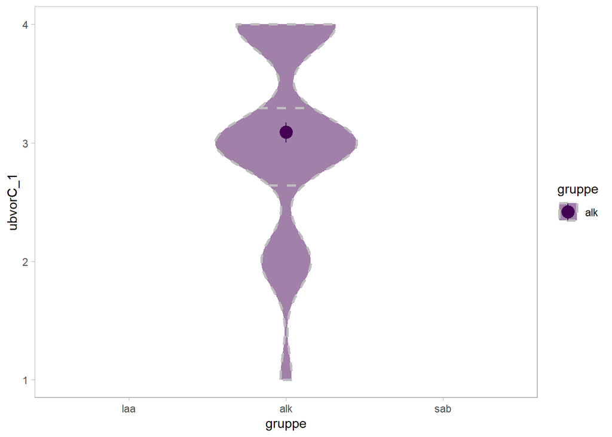

```r
violin_plot(nrw_p,
            eval(p_var),
            eval(p_vergleich))
```

**Deskriptive Ergebnisse**

In der Spalte “group1” wird angezeigt, um welche Gruppe (Nummer der Kohorte oder Gruppe) es sich in der jeweiligen Zeile handelt

```r
psych::describeBy(nrw_p[[p_var]],
                  group = droplevels(nrw_p[[p_vergleich]]),
                  mat=TRUE,
                  digits=3)
```

```
    item group1 vars   n  mean    sd median trimmed   mad min  max range   skew
X11    1    laa    1   0   NaN    NA     NA     NaN    NA Inf -Inf  -Inf     NA
X12    2    alk    1 318 3.091 0.799      3    3.16 1.483   1    4     3 -0.608
X13    3    sab    1   0   NaN    NA     NA     NaN    NA Inf -Inf  -Inf     NA
    kurtosis    se
X11       NA    NA
X12   -0.107 0.045
X13       NA    NA
```

**Kohorten und Gruppen mit Daten**

Anzahl der Teilnehmenden je Gruppe und Kohorte:

```r
nrw %>%
  dplyr::filter(!is.na(get(p_var))) %>%
  {table(.$gruppe, .$kohorte)}
```

```
        1   2   3   4
  laa   0   0   0   0
  alk   0   0   0 318
  sab   0   0   0   0
```

### 2.4.8 Nachbesprechung UB

**Abbildung**

```r
rm(p_var)
rm(p_vergleich)
rm(p_kohorten)
rm(p_gruppe)

############################################### #
### Welche VARIABLE soll ausgegeben werden?   ###
############################################### #
# p_var <- "" # Variable in Anführungszeichen angeben

############################################### #
### Welcher VERGLEICH soll angestellt werden? ###
############################################### #
p_vergleich <- "gruppe" # Möglich ist: "kohorte" oder "gruppe"

############################################### #
### Welche KOHORTEN sollen ausgegeben werden? ###
############################################### #
p_kohorten <- c("4") # Verfügbar: "1", "2", "3", "4"
                          # Einfach auskommentieren, wenn
                          # alle ausgegeben werden sollen

############################################### #
### Welche GRUPPEN sollen ausgegeben werden?  ###
############################################### #
# p_gruppe <- c("laa") # Verfügbar: "laa" (Lehramtsanwärter*innen),
                     #            "sab" (Seminarausbilder*innen)
                     #            "alk" (Ausbildungslehrkräfte)
                     # Einfach auskommentieren, wenn
                     # alle ausgegeben werden sollen

nrw_p <- nrw
if (exists("p_kohorten")) {
  nrw_p <- nrw_p |>
    dplyr::filter(kohorte %in% p_kohorten)
}
if (exists("p_gruppe")) {
  nrw_p <- nrw_p |>
    dplyr::filter(gruppe %in% p_gruppe)
}
```

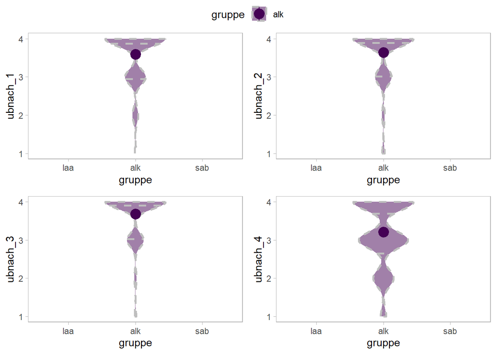

```r
p_var <- "ubnach_1" # Variable in Anführungszeichen angeben
p1 <- violin_plot(nrw_p,
            eval(p_var),
            eval(p_vergleich))

p_var <- "ubnach_2" # Variable in Anführungszeichen angeben
p2 <- violin_plot(nrw_p,
            eval(p_var),
            eval(p_vergleich))

p_var <- "ubnach_3" # Variable in Anführungszeichen angeben
p3 <- violin_plot(nrw_p,
            eval(p_var),
            eval(p_vergleich))

p_var <- "ubnach_4" # Variable in Anführungszeichen angeben
p4 <- violin_plot(nrw_p,
            eval(p_var),
            eval(p_vergleich))

ggarrange(p1, p2, p3, p4,
          ncol = 2,
          nrow = 2,
          align = "hv",
          common.legend = T)
```

**Deskriptive Ergebnisse**

In der Spalte “group1” wird angezeigt, um welche Gruppe (Nummer der Kohorte oder Gruppe) es sich in der jeweiligen Zeile handelt

```r
psych::describeBy(nrw_p[[p_var]],
                  group = droplevels(nrw_p[[p_vergleich]]),
                  mat=TRUE,
                  digits=3)
```

```
    item group1 vars   n  mean    sd median trimmed   mad min  max range   skew
X11    1    laa    1   0   NaN    NA     NA     NaN    NA Inf -Inf  -Inf     NA
X12    2    alk    1 319 3.213 0.846      3   3.315 1.483   1    4     3 -0.822
X13    3    sab    1   0   NaN    NA     NA     NaN    NA Inf -Inf  -Inf     NA
    kurtosis    se
X11       NA    NA
X12   -0.118 0.047
X13       NA    NA
```

**Kohorten und Gruppen mit Daten**

Anzahl der Teilnehmenden je Gruppe und Kohorte:

```r
nrw %>%
  dplyr::filter(!is.na(get(p_var))) %>%
  {table(.$gruppe, .$kohorte)}
```

```
        1   2   3   4
  laa   0   0   0   0
  alk   0   0   0 319
  sab   0   0   0   0
```

# 3 Computational environment

## 3.1 Packages

```r
installed.packages()[names(sessionInfo()$otherPkgs), "Version"]
```

```
   ggpubr     psych     Hmisc lubridate   forcats   stringr     dplyr     purrr
  "0.6.0"   "2.4.3"   "5.1-2"   "1.9.3"   "1.0.0"   "1.5.1"   "1.1.4"   "1.0.2"
    readr     tidyr    tibble   ggplot2 tidyverse      here       rio
  "2.1.4"   "1.3.1"   "3.2.1"   "3.5.1"   "2.0.0"   "1.0.1"   "1.0.1"
```

## 3.2 R Version

```r
R.Version()
```

```
$platform
[1] "x86_64-w64-mingw32"

$arch
[1] "x86_64"

$os
[1] "mingw32"

$crt
[1] "ucrt"

$system
[1] "x86_64, mingw32"

$status
[1] ""

$major
[1] "4"

$minor
[1] "3.3"

$year
[1] "2024"

$month
[1] "02"

$day
[1] "29"

$`svn rev`
[1] "86002"

$language
[1] "R"

$version.string
[1] "R version 4.3.3 (2024-02-29 ucrt)"

$nickname
[1] "Angel Food Cake"
```